# 03 线性回归（三）

2025-9-23

课程代码均在如下 GitHub 仓库开源：https://github.com/GHe0000/xmu_machine_learning

项目自动生成网页地址：https://ghe0000.github.io/xmu_machine_learning

## 目录

- 作业要求
- 背景补充
  - Legendre 多项式
  - `np.linalg.lstsq`
  - 奇异值与数值稳定性
- 数据预处理：数据生成，数据集划分
  - 计算准备
  - 生成数据集
- 使用 Legendre 多项式进行拟合
  - 损失函数定义
  - 特征矩阵构造
  - 模型训练
  - 拟合结果分析
- MSE 随参数数变化
  - 奇异值随参数量变化
- bias-variance-noise 分解理论验证
- 对比普通多项式基底
  - 使用普通多项式基底拟合
- Legendre 多项式基底特征标准化影响
  - 数值探索
  - 理论分析
  - 进一步验证
- 结论
- 参考资料以及 AI 使用说明
- 致谢
- 附一：问题
- 附二：学习心得

## 作业要求

延用第一次作业的数据生成方式，但做如下限定：

- 训练集 40 个点，验证集 800 个点
- 权重数的范围从 2 到 120
- 用 Legendre 基函数 (自行了解，并写入背景)
- 用 `np.linalg.lstsq` 求解线性回归权重（自行了解这一算法，并写入背景）

完成一下数值实验：

- 画出训练集平均平方误差和验证集平均平方误差随权重数的变化曲线，它是否是预期的样子？试分析原因。
- 验证集平方误差是否符合 bias-variance-noise 分解理论？试验证。（可选）
- 对比多项式基函数的结果，并分析异同（可选）

## 背景补充

### Legendre 多项式

第一次作业中使用普通幂函数

$$ 1,x,x^2,\dots,x^n $$

作为多项式基底. 这组基底虽然能够张成全部 $n$ 阶多项式空间, 但不同基函数之间并不正交, 随着阶数增加会使数据矩阵不同列之间出现较强的相关性, 从而导致矩阵条件数增大和数值求解困难.

由于本题中 $x$ 在 $[-1,1]$ 上均匀采样, 定义内积

$$ \langle f,g\rangle=\int_{-1}^{1}f(x)g(x)\,dx $$

从普通幂函数 $1,x,x^2,\dots$ 出发进行 Gram-Schmidt 正交化

$$ u_n(x)=x^n-\sum_{k=0}^{n-1}\frac{\langle x^n,u_k\rangle}{\langle u_k,u_k\rangle}u_k(x) $$

下面逐阶计算. 零阶，首先取

$$ u_0(x)=1 $$

不需要进行任何处理. 其模平方为

$$ \langle u_0,u_0\rangle =\int_{-1}^{1}1\,dx=2 $$

按照 Legendre 多项式的归一化条件，直接得到

$$ P_0(x)=1 $$

一阶，从 $v_1=x$ 出发, 减去其在 $u_0=1$ 上的投影

$$ u_1(x) =x-\frac{\langle x,1\rangle} {\langle1,1\rangle} $$

而由于积分区间关于原点对称, $x$ 是奇函数, 因此

$$ \langle x,1\rangle =\int_{-1}^{1}x\,dx=0 $$

所以

$$ u_1(x)=x $$

从而得到

$$ P_1(x)=x $$

二阶，从 $v_2=x^2$，出发, 需要减去它分别在 $u_0$ 和 $u_1$ 方向上的投影

$$ u_2 =x^2 -\frac{\langle x^2,u_0\rangle}{\langle u_0,u_0\rangle}u_0 -\frac{\langle x^2,u_1\rangle}{\langle u_1,u_1\rangle}u_1 $$

分别计算内积

$$ \begin{aligned} \langle x^2,1\rangle &=\int_{-1}^{1}x^2\,dx=\frac23 \\ \langle1,1\rangle &=2 \\ \langle x^2,x\rangle &=\int_{-1}^{1}x^3\,dx=0 \end{aligned} $$

因此 $x^2$ 在 $u_0$ 方向上的投影为

$$ \frac{\langle x^2,1\rangle}{\langle1,1\rangle} =\frac{2/3}{2} =\frac13 $$

而在 $u_1=x$ 方向上的投影为零. 所以

$$ u_2(x)=x^2-\frac13 $$

此时

$$ u_2(1)=1-\frac13=\frac23 $$

还不满足 $P_2(1)=1$, 因此乘以 $3/2$

$$ P_2(x) =\frac32u_2(x) =\frac12(3x^2-1) $$

三阶，同样从 $v_3=x^3$ 出发

$$ u_3=x^3 -\frac{\langle x^3,u_0\rangle}{\langle u_0,u_0\rangle}u_0 -\frac{\langle x^3,u_1\rangle}{\langle u_1,u_1\rangle}u_1 -\frac{\langle x^3,u_2\rangle}{\langle u_2,u_2\rangle}u_2 $$

由于 $x^3$ 是奇函数, $u_0$ 和 $u_2$ 都是偶函数, 所以

$$ \langle x^3,u_0\rangle=0,\qquad \langle x^3,u_2\rangle=0 $$

只剩下在 $u_1=x$ 上的投影. 计算

$$ \begin{aligned} \langle x^3,x\rangle&=\int_{-1}^{1}x^4\,dx=\frac25 \\ \langle x,x\rangle&=\int_{-1}^{1}x^2\,dx=\frac23 \end{aligned} $$ 因此投影系数为

$$ \frac{\langle x^3,x\rangle}{\langle x,x\rangle} =\frac{2/5}{2/3} =\frac35 $$

从而

$$ u_3(x)=x^3-\frac35x $$

而

$$ u_3(1)=1-\frac35=\frac25 $$

因此需要乘以 $5/2$

$$ P_3(x) =\frac52u_3(x) =\frac52\left(x^3-\frac35x\right) =\frac12(5x^3-3x) $$

因此前四个 Legendre 多项式为

$$ \begin{aligned} P_0(x)&=1\\ P_1(x)&=x\\ P_2(x)&=\frac12(3x^2-1)\\ P_3(x)&=\frac12(5x^3-3x) \end{aligned} $$

一般情况下

$$ \begin{aligned} P_n(x)&=\frac{(2n-1)xP_{n-1}(x)-(n-1)P_{n-2}(x)}{n} \\ \int_{-1}^{1}P_m(x)P_n(x)\,dx&=\frac{2}{2n+1}\delta_{mn} \end{aligned} $$

Legendre 多项式与普通幂函数张成相同的多项式空间, 因此并没有改变模型理论上的表达能力, 而是重新选择了一组数值性质更好的坐标基底.

### `np.linalg.lstsq`

正规方程可以写为

$$ X^T X\mathbf w=X^T\mathbf y $$

当 $X$ 满列秩时，可以进一步写成

$$ \mathbf w^*=(X^TX)^{-1}X^T\mathbf y $$

但实际数值计算中通常没有必要显式构造 $(X^TX)^{-1}$. 特别是当 $X$ 已经病态时，构造 $X^TX$ 会进一步恶化数值条件.

因此本实验直接使用 `np.linalg.lstsq` 基于奇异值分解求解最小二乘问题.

```
w, residuals, rank, s = np.linalg.lstsq(X, y, rcond=None)
```

当最小二乘解不唯一时, np.linalg.lstsq 返回其中参数范数 $||\mathbf w||_2$ 最小的解. 同时可以得到矩阵的数值秩 rank 和奇异值 s.

### 奇异值与数值稳定性

在线性回归中, 设计矩阵记为

$$ X\in\mathbb R^{N\times p} $$

其中 $N$ 为训练样本数, $p=n_{weight}$ 为模型参数个数. 最小二乘问题可以写为

$$ \min_{\boldsymbol\theta}\|X\boldsymbol\theta-\mathbf y\|_2^2 $$

为了分析设计矩阵的数值性质, 可以对 $X$ 进行奇异值分解

$$ X=U\Sigma V^T $$

其中 $U$ 和 $V$ 为正交矩阵, $\Sigma$ 为对角矩阵, 其对角元素

$$ \sigma_1\ge\sigma_2\ge\cdots\ge\sigma_r>0 $$

称为 $X$ 的奇异值, 其中 $r=\operatorname{rank}(X)$.

从几何上看, $V$ 中的向量给出参数空间中的不同方向, 而奇异值 $\sigma_i$ 描述设计矩阵将这些方向映射到训练数据空间后被放大或缩小的程度. 对某个右奇异向量 $\mathbf v_i$ 有

$$ X\mathbf v_i=\sigma_i\mathbf u_i $$

因此如果 $\sigma_i$ 很大, 参数沿该方向发生变化时会明显改变模型在训练点上的输出. 如果 $\sigma_i$ 很小, 即使参数沿该方向发生较大变化, 在训练点上的输出也可能只有很小变化.

其中最小非零奇异值

$$ \sigma_{\min} $$

尤其重要. 它可以写为

$$ \sigma_{\min}(X)= \min_{\|\mathbf w\|_2=1} \|X\mathbf w\|_2 $$

因此 $\sigma_{\min}$ 可以理解为设计矩阵中最不稳定方向的强度. 当 $\sigma_{\min}$ 很小时, 说明存在一组并不小的参数变化, 但这些基函数在训练点上的作用几乎相互抵消. 此时模型参数很难由训练数据唯一且稳定地确定.

## 数据预处理：数据生成，数据集划分

### 计算准备

导入需要的库，并针对 Jupyter Notebook 进行一些设置.

```python
import numpy as np # 数值计算库
import numba as nb # 引入 jit 来加速函数（如果需要）
import sympy as sym # 符号计算库
import matplotlib as mpl
import matplotlib.pyplot as plt # 图像绘制
from matplotlib.backends.backend_agg import FigureCanvasAgg # 设置图像后端用
import ipywidgets as ipw # 交互控件
from IPython.display import display, Math, Latex # 打印数学公式
import time
import tracemalloc

import pandas as pd

from io import BytesIO
import matplotlib.animation as animation # 创建动画
from IPython.display import HTML # 动画嵌入
import scipy

# 使用 mathjax 来在 jupyter notebook 显示数学公式
sym.init_printing(use_latex='mathjax')

# 设置 matplotlib 绘制的图像嵌入到 jupyter notebook 的方式
%matplotlib widget

# 一个工具函数，可以让静态图片不经过 widget 直接嵌入 Jupyter notebook
# 这样图片可以直接存到 nb 文件里，而不是需要运行才能显示（类似 inline）
def display_inline(fig):
    try:
        try:
            fig.canvas.draw()
            fig.canvas.flush_events()
        except Exception:
            pass

        fig.set_canvas(FigureCanvasAgg(fig))
        try:
            import matplotlib.text as mtext

            if hasattr(mtext, "_get_text_metrics_with_cache_impl"):
                mtext._get_text_metrics_with_cache_impl.cache_clear()
        except Exception:
            pass
        try:
            fig.draw_without_rendering()
        except Exception:
            pass
        fig.tight_layout()
        fig.canvas.draw()
        display(fig)

    finally:
        plt.close(fig)  # 释放 fig，减小资源消耗

# 一个工具函数，用于在 Jupyter 中快速实现公式和字符串混合输出
def display_math(*args):
    parts = []
    for a in args:
        if isinstance(a, str):
            parts.append(a)
        else:
            parts.append(sym.latex(a))
    display(Math("".join(parts)))

# 设置 matplotlib 使用的字体，避免出现中文问题
plt.rcParams.update({
    # 字体
    "font.family": ["SimSun", "Times New Roman"],
    "font.size": 14,
    "mathtext.fontset": "cm",
    "axes.unicode_minus": False,

    # 字号
    "axes.titlesize": 14,
    "axes.labelsize": 14,
    "xtick.labelsize": 14,
    "ytick.labelsize": 14,
    "legend.fontsize": 14,
    "figure.titlesize": 14,
})

# 设置种子，保证可重复性
rng = np.random.default_rng(3407)
```

### 生成数据集

根据题目要求，$y(x) = 2x + \sin 26 x + \xi$ 构造数据集，其中 $ x \in [-1,1]$, $\xi$ 为 $[-1,1]$ 区间均匀分布随机数，噪声幅度定为 $0.2$. 随机采样 840 个点，并绘制在图中.

```python
N = 840 # 数据集大小
noise_amplitude = 0.2 # 噪声幅度
x_data = rng.uniform(-1, 1, N)
xi = rng.uniform(-1, 1, N) * noise_amplitude
y_data = 2 * x_data + np.sin(26 * x_data) + xi

x_true = np.linspace(-1, 1, 1000)
y_true = 2 * x_true + np.sin(26 * x_true)
```

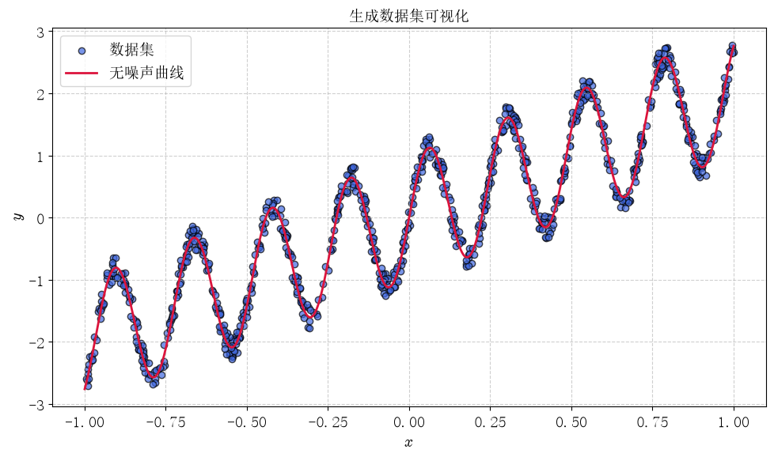

```python
fig, ax = plt.subplots(figsize=(10, 6))

ax.scatter(
    x_data, y_data, color="royalblue", alpha=0.7, edgecolors="k", label="数据集"
)

ax.plot(
    x_true,
    y_true,
    color="crimson",
    linewidth=2,
    label="无噪声曲线",
)

ax.set_title("生成数据集可视化")
ax.set_xlabel(r"$x$")
ax.set_ylabel(r"$y$")
ax.grid(True, linestyle="--", alpha=0.6)
ax.legend()
display_inline(fig)
```

840 个数据，按题目要求划分训练集和验证集，其中训练集 40 个点，验证集 800 个点，并绘制划分完成的训练集和测试集：

```python
indices = rng.permutation(N)
train_idx = indices[:40]; val_idx = indices[40:]

x_train = x_data[train_idx]; y_train = y_data[train_idx]
x_val = x_data[val_idx]; y_val = y_data[val_idx]

print(f"训练集大小：{x_train.shape}")
print(f"验证集大小：{x_val.shape}")
```

```
训练集大小：(40,)
验证集大小：(800,)
```

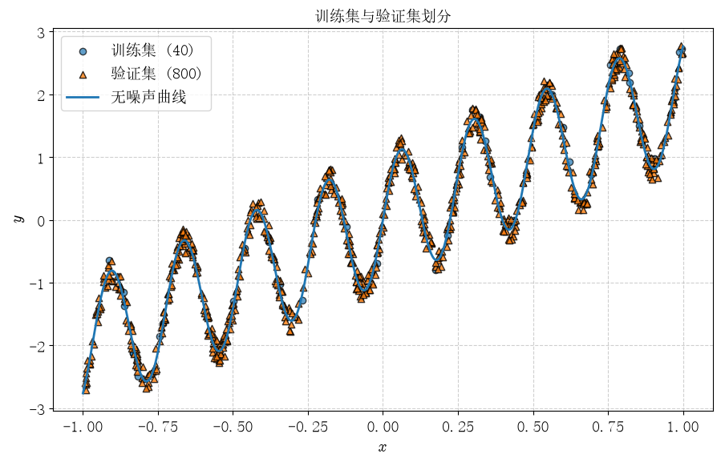

```python
fig, ax = plt.subplots(figsize=(10, 6))
# 训练集
ax.scatter(
    x_train,
    y_train,
    alpha=0.7,
    edgecolors="k",
    label=f"训练集 ({len(x_train)})",
)

# 测试集
ax.scatter(
    x_val,
    y_val,
    alpha=0.8,
    edgecolors="k",
    marker="^",
    label=f"验证集 ({len(x_val)})",
)

# 无噪声真实曲线
ax.plot(
    x_true,
    y_true,
    linewidth=2,
    label="无噪声曲线",
)

ax.set_title("训练集与验证集划分")
ax.set_xlabel(r"$ x $")
ax.set_ylabel(r"$ y $")
ax.grid(True, linestyle="--", alpha=0.6)
ax.legend()
display_inline(fig)
```

## 使用 Legendre 多项式进行拟合

### 损失函数定义

损失函数仍旧使用 MSE：

$$ MSE(w) = \frac{1}{n} (y_{pred}-y)^T (y_{pred}-y) $$

函数实现如下：

```python
@nb.njit()
def mse_function(y_pred, y):
    m = y.size
    error = y_pred - y
    return (error.T @ error) / m
```

对于理想情况下，如果模型能完美学习到真实函数，则单个样本的预测误差只有噪声，此时理论的最低 MSE 为：

$$ \mathbb{E}((y_{pred}-y)^2) = \mathbb{E}(\xi^2)=a^2/3 $$ 其中 $a$ 为噪声幅度. 这里 $a=0.2$

### 特征矩阵构造

根据 Legendre 多项式递推关系

$$ P_0(x)=1,\qquad P_1(x)=x,\qquad P_n(x)=\frac{(2n-1)xP_{n-1}(x)-(n-1)P_{n-2}(x)}{n} $$

对于具有 $p$ 个权重的模型，构造特征矩阵

$$ X= \begin{bmatrix} P_0(x_1)&P_1(x_1)&\cdots&P_{p-1}(x_1)\\ P_0(x_2)&P_1(x_2)&\cdots&P_{p-1}(x_2)\\ \vdots&\vdots&&\vdots\\ P_0(x_N)&P_1(x_N)&\cdots&P_{p-1}(x_N) \end{bmatrix} $$

```python
@nb.njit(parallel=True)
def legendre(x, n_weight):
    X = np.empty((x.size, n_weight), dtype=np.float64)
    for i in nb.prange(x.size):
        X[i, 0] = 1.0
        if n_weight > 1: X[i, 1] = x[i]
        for n in range(2, n_weight):
            X[i, n] = ((2*n-1)*x[i]*X[i, n-1]-(n-1)*X[i, n-2])/n
    return X

max_weight = 120
X_train_all = legendre(x_train, max_weight)
X_val_all = legendre(x_val, max_weight)
X_true_all = legendre(x_true, max_weight)
```

这里是否标准化需要进行讨论，因为 Legendre 多项式是在 $[-1,1]$ 上的正交基底，如果进行标准化，会加减常数，相当于使用 $P_n - c_n P_0$ 作为新基底，可能会改变我们的正交性. 后续我们会进行对比实验说明.

这里我们先不进行标准化.

### 模型训练

对于给定权重数 $p$，取预先构造的 Legendre 特征矩阵前 $p$ 列，并使用 `np.linalg.lstsq` 求解

$$ \mathbf w^* =\underset{\mathbf w}{\arg\min} \|X\mathbf w-\mathbf y\|_2^2 $$

先人为取参数数 $n_{weight}=20$，进行拟合（之后会改变来讨论），此时有：

```python
n_weight = 20
X = X_train_all[:, :n_weight]
w, residuals, rank, s = np.linalg.lstsq(X, y_train, rcond=None)
train_mse_single = mse_function(X_train_all[:,:n_weight] @ w, y_train)
val_mse_single = mse_function(X_val_all[:,:n_weight] @ w, y_val)

print(f"权重数：{n_weight}")
print(f"矩阵秩：{rank}")
print(f"训练集 MSE：{train_mse_single:.6g}")
print(f"验证集 MSE：{val_mse_single:.6g}")
```

```
权重数：20
矩阵秩：20
训练集 MSE：0.2048
验证集 MSE：2198.88
```

### 拟合结果分析

绘制上述拟合结果图像，有：

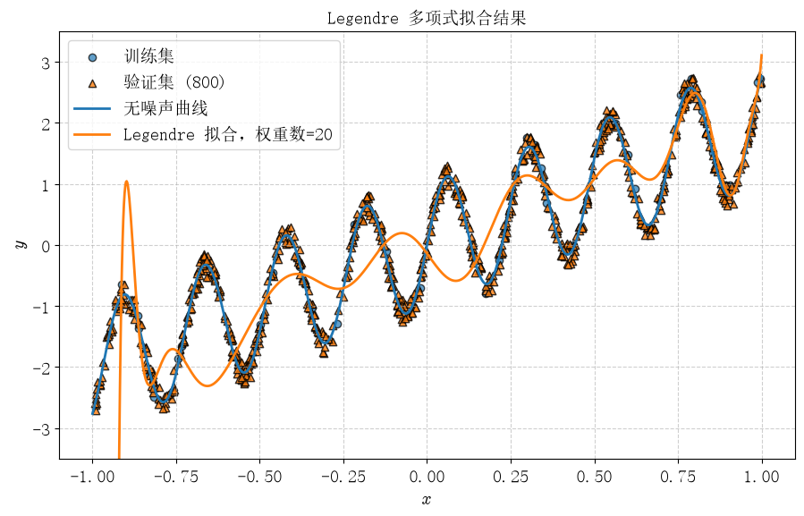

```python
fig, ax = plt.subplots(figsize=(10, 6))

ax.scatter(
    x_train,
    y_train,
    alpha=0.7,
    edgecolors="k",
    label="训练集",
)

ax.scatter(
    x_val,
    y_val,
    alpha=0.8,
    edgecolors="k",
    marker="^",
    label=f"验证集 ({len(x_val)})",
)

ax.plot(
    x_true,
    y_true,
    linewidth=2,
    label="无噪声曲线",
)

ax.plot(
    x_true,
    X_true_all[:, :n_weight] @ w,
    linewidth=2,
    label=f"Legendre 拟合，权重数={n_weight}",
)

ax.set_xlabel(r"$x$")
ax.set_ylabel(r"$y$")
ax.set_ylim(-3.5,3.5)
ax.set_title("Legendre 多项式拟合结果")
ax.grid(True, linestyle="--", alpha=0.6)
ax.legend()

display_inline(fig)
```

可以看见，此时拟合结果已经表现出明显的不稳定性. 当权重数取 $20$ 时，模型最高使用到 $P_{19}(x)$，对于目标函数中 $\sin 26x$ 的快速振荡仍然缺乏足够的稳定表达能力.

## MSE 随参数数变化

令权重数

$$ p=2,3,\dots,120 $$

对权重数进行并行扫描，进行线性拟合并计算 MSE.

```python
@nb.njit(parallel=True)
def sweep_lstsq(X_train_all, y_train, X_val_all, y_val, n_weights):
    n_model = n_weights.size
    train_mse = np.empty(n_model)
    val_mse = np.empty(n_model)
    rank_all = np.empty(n_model, dtype=np.int64)
    s_min = np.empty(n_model)
    condition = np.empty(n_model)
    for i in nb.prange(n_model):
        p = n_weights[i]
        X_train = X_train_all[:, :p].copy()
        X_val = X_val_all[:, :p].copy()
        w, _, rank, s = np.linalg.lstsq(
            X_train, y_train, rcond=-1.0
        )
        train_mse[i] = np.mean((X_train @ w - y_train)**2)
        val_mse[i] = np.mean((X_val @ w - y_val)**2)
        rank_all[i] = rank
        s_min[i] = s[-1]
        condition[i] = s[0] / s[-1] if s[-1] > 0 else np.inf
    return train_mse, val_mse, rank_all, s_min, condition

n_weights = np.arange(2, 121)

# 预编译
_, _, _, _, _ = sweep_lstsq(
    X_train_all, y_train, X_val_all, y_val, n_weights[:2]
)
t_start = time.time()
print("开始扫描...")
train_mse, val_mse, rank_all, s_min, condition = sweep_lstsq(
    X_train_all, y_train, X_val_all, y_val, n_weights
)
print(f"结束，耗时：{time.time()-t_start:.3f} s")
```

```
开始扫描...
结束，耗时：0.054 s
```

绘制 MSE 随参数量的图：

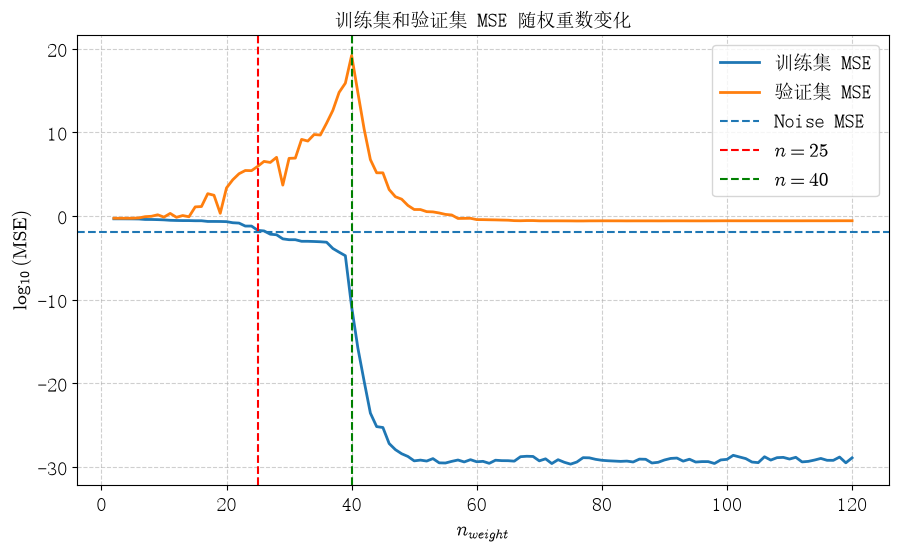

```python
fig, ax = plt.subplots(figsize=(10, 6))
log_train = np.log10(train_mse)
log_val   = np.log10(val_mse)
ax.plot(n_weights, log_train, linewidth=2, label="训练集 MSE")
ax.plot(n_weights, log_val,   linewidth=2, label="验证集 MSE")
ax.axhline(np.log10(noise_amplitude**2 / 3), linestyle="--", linewidth=1.5, label=fr"Noise MSE")
ax.axvline(25, linestyle="--", color="r", linewidth=1.5, label="$n=25$")
ax.axvline(40, linestyle="--", color="g", linewidth=1.5, label="$n=40$")
ax.set_ylabel("$ \\log_{10}(\\mathrm{MSE}) $")
ax.set_xlabel("$ n_{weight} $")
ax.set_title("训练集和验证集 MSE 随权重数变化")
ax.grid(True, linestyle="--", alpha=0.6)
ax.legend()
display_inline(fig)
```

可见, 当 $n_{weight}$ 较小时, 增加参数量会降低训练误差, 但验证误差并没有同步下降. 在 $n_{weight}\approx25$ 以后, 训练 MSE 已经低于理论 Noise MSE, 说明模型开始明显拟合训练样本中的噪声和采样偶然性.

继续增加参数量进入 $p>N$ 的欠定区域后, 训练误差保持接近零, 但验证误差从插值峰显著回落.

因此本实验得到的并不一定是传统的简单 U 型曲线，为了直观观察模型复杂度增加对拟合结果的影响, 选取若干具有代表性的权重数, 同时绘制真实理论函数、最小二乘拟合函数、训练集以及测试集数据点.

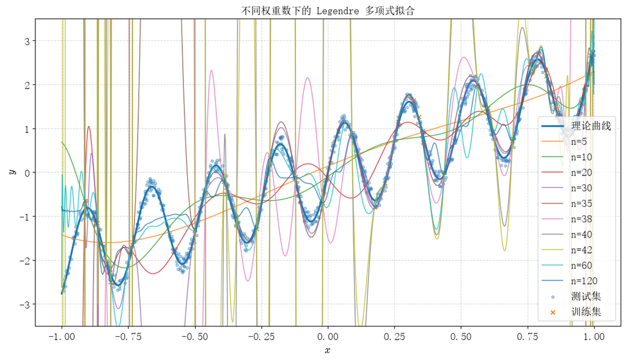

```python
fit_weights = [5, 10, 20, 30, 35, 38, 40, 42, 60, 120]

x_plot = np.linspace(-1, 1, 2000)
y_true = 2*x_plot + np.sin(26*x_plot)
X_plot = legendre(x_plot, max_weight)

fig, ax = plt.subplots(figsize=(12, 7))
ax.plot(x_plot, y_true, linewidth=2.5, label="理论曲线")

for p in fit_weights:
    X = X_train_all[:, :p].copy()
    w = np.linalg.lstsq(X, y_train, rcond=None)[0]
    y_fit = X_plot[:, :p] @ w
    ax.plot(x_plot, y_fit, linewidth=1.2, alpha=0.8, label=rf"n={p}")

ax.scatter(x_val, y_val, s=14, alpha=0.35, label="测试集")
ax.scatter(x_train, y_train, s=28, marker="x", label="训练集")

ax.set_title("不同权重数下的 Legendre 多项式拟合")
ax.set_xlabel("$x$"); ax.set_ylabel("$y$")
ax.set_ylim(-3.5,3.5)
ax.grid(True, linestyle="--", alpha=0.5)
ax.legend()
display_inline(fig)
```

这里也可以看见，在 $n_{weight}$ 接近训练集大小时，拟合函数的振荡非常剧烈，虽然训练集误差变小，但拟合函数却更不吻合目标函数.

当 $n_{weight} > 40$ 也就是进入欠定区域后，拟合看书开始接近目标函数，并最终得到较好的拟合.

### 奇异值随参数量变化

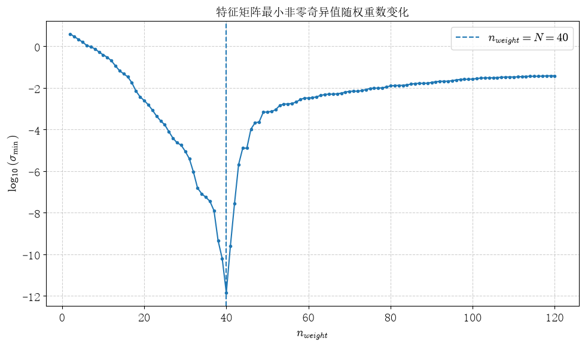

```python
singular_values = []
sigma_min = np.empty(len(n_weights)); sigma_max = np.empty(len(n_weights))
condition_svd = np.empty(len(n_weights))

for i, p in enumerate(n_weights):
    s = np.linalg.svd(X_train_all[:, :p], compute_uv=False)
    singular_values.append(s)
    sigma_max[i], sigma_min[i] = s[0], s[-1]
    condition_svd[i] = s[0]/s[-1]

fig, ax = plt.subplots(figsize=(10, 6))
ax.plot(n_weights, np.log10(sigma_min), marker="o", markersize=3)
ax.axvline(len(x_train), linestyle="--", linewidth=1.5, label=r"$n_{weight}=N=40$")
ax.set_title("特征矩阵最小非零奇异值随权重数变化")
ax.set_xlabel(r"$n_{weight}$"); ax.set_ylabel(r"$\log_{10}(\sigma_{\min})$")
ax.grid(True, linestyle="--", alpha=0.6); ax.legend()
display_inline(fig)
```

最小正奇异值的变化可以直接反映插值峰附近的数值稳定性. 当 $p<40$ 时，设计矩阵通常满列秩，此时最小正奇异值就是通常意义下的最小奇异值. 随着特征数增加，设计矩阵出现越来越弱的参数方向，最小奇异值不断减小，因此训练数据中很小的噪声和采样扰动可能被伪逆显著放大到模型系数和预测结果中.

在 $p=40$ 附近，$X$ 接近方阵且最小正奇异值达到极小值，因此验证误差出现尖峰.

当 $p>40$ 后，可以看到该值逐渐增大，对应伪逆在有效方向上的噪声放大程度下降，因此验证误差也从插值峰重新回落.

最小奇异值可以理解为设计矩阵中“最不稳定方向”的强弱. 当 $\sigma_{\min}$ 很小时, 说明存在一组并不大的系数组合, 可以让不同基函数在训练点上几乎相互抵消. 这时只要训练数据发生很小变化, 求出的系数就可能发生很大变化.

当 $p<N$ 时, 每增加一个基函数, 模型就多一个可以组合和相互抵消的方向. 因此随着参数量增加, 更容易找到一个在训练点上几乎相互抵消的组合, 最小奇异值通常会逐渐减小.

当 $p=N=40$ 时, 参数个数刚好等于训练样本数. 此时模型已经具有足够自由度去精确穿过所有训练点, 同时又没有额外的冗余自由度. 因此系统最容易出现一种情况: 某些高阶基函数在训练点上几乎互相抵消, 但在训练点之间却产生很大的振荡. 于是最小奇异值在这里降到最低, 模型也最不稳定.

当 $p>N$ 后，参数数量超过训练样本数，设计矩阵开始具有非平凡零空间. 此时严格意义下的最小奇异值已经为零，因此应当考察最小正奇异值.

若向设计矩阵中增加一个新的特征列 $\mathbf z$，则有

$$ X_{p+1}X_{p+1}^T= X_pX_p^T+\mathbf z\mathbf z^T $$

其中 $\mathbf z\mathbf z^T$ 为半正定矩阵，因此

$$ X_{p+1}X_{p+1}^T \succeq X_pX_p^T $$

当设计矩阵已经满行秩时，其最小特征值不会因为增加新的特征列而减小，因此最小正奇异值

$$ \sigma_{\min}^{+}(X)= \sqrt{\lambda_{\min}(XX^T)} $$

也不会继续减小，并可能随着新特征对薄弱方向的补充而逐渐增大.

因此 $p=N=40$ 附近正好对应最小奇异值的谷底, 也对应验证误差的插值峰.

## bias-variance-noise 分解理论验证

对于平方损失，在固定输入 $x$ 上有

$$ \begin{aligned} \mathbb E_{D,\xi}\left[(y-\hat f_D(x))^2\right] &=\left[f(x)-\mathbb E_D\hat f_D(x)\right]^2 +\mathbb E_D\left[\left(\hat f_D(x)-\mathbb E_D\hat f_D(x)\right)^2\right] +\sigma_\xi^2 \\ &=\mathrm{Bias}^2+\mathrm{Variance}+\mathrm{Noise} \end{aligned} $$

其中本实验噪声满足 $\xi\sim U(-0.2,0.2)$，因此

$$ \sigma_\xi^2=\frac{0.2^2}{3}\approx0.01333 $$

由于 Bias 和 Variance 需要对不同训练数据集取平均，因此通过 Monte Carlo 方法重复生成训练数据并重新拟合模型进行验证. 每一个权重数重复 1000 次.

```python
weights_bv = np.arange(2, 121, 2, dtype=np.int64)

N_repeat = 1000
N_eval = 800

x_train_mc = rng.uniform(-1, 1, (N_repeat, 40))
y_train_mc = 2*x_train_mc + np.sin(26*x_train_mc) + rng.uniform(
    -noise_amplitude, noise_amplitude, (N_repeat, 40)
)

x_eval = np.linspace(-1, 1, N_eval)
f_eval = 2*x_eval + np.sin(26*x_eval)

y_eval_mc = f_eval[None, :] + rng.uniform(
    -noise_amplitude, noise_amplitude, (N_repeat, N_eval)
)

@nb.njit(parallel=True)
def legendre_batch(x, n_weight):
    X = np.empty((x.shape[0], x.shape[1], n_weight), dtype=np.float64)

    for r in nb.prange(x.shape[0]):
        for i in range(x.shape[1]):
            X[r, i, 0] = 1.0
            if n_weight > 1: X[r, i, 1] = x[r, i]
            for n in range(2, n_weight):
                X[r, i, n] = ((2*n-1)*x[r, i]*X[r, i, n-1]-(n-1)*X[r, i, n-2])/n

    return X

X_train_mc = legendre_batch(x_train_mc, max_weight)
X_eval = legendre(x_eval, max_weight)
```

对不同的参数量进行并行计算：

```python
@nb.njit(parallel=True)
def bias_variance_scan(X_train_mc, y_train_mc, X_eval, f_eval, y_eval_mc, n_weights):
    n_model, N_repeat, N_eval = n_weights.size, X_train_mc.shape[0], X_eval.shape[0]
    bias2 = np.empty(n_model); variance = np.empty(n_model); test_mse = np.empty(n_model)
    eps = np.finfo(np.float64).eps

    for k in nb.prange(n_model):
        p = n_weights[k]
        Xev = X_eval[:, :p].copy()  # 转为 C-contiguous, 每个 p 只复制一次
        sum_pred = np.zeros(N_eval); sum_pred2 = np.zeros(N_eval); mse_sum = 0.0
        for r in range(N_repeat):
            X = X_train_mc[r, :, :p].copy()
            w = np.linalg.lstsq(X, y_train_mc[r], rcond=eps*max(X.shape))[0]
            pred = Xev @ w
            sum_pred += pred; sum_pred2 += pred*pred
            mse_sum += np.sum((pred-y_eval_mc[r])**2)

        mean_pred = sum_pred/N_repeat
        bias2[k] = np.mean((mean_pred-f_eval)**2)
        variance[k] = np.mean(np.maximum(sum_pred2/N_repeat-mean_pred**2, 0.0))
        test_mse[k] = mse_sum/(N_repeat*N_eval)

    return bias2, variance, test_mse

t_start = time.time()
print("开始扫描......")
bias2, variance, test_mse_mc = bias_variance_scan(
    X_train_mc, y_train_mc, X_eval, f_eval, y_eval_mc, weights_bv
)
print(f"扫描结束，用时：{time.time()-t_start:.3f} s")

noise = np.full(weights_bv.size, noise_amplitude**2/3)
bvn_sum = bias2 + variance + noise
```

```
开始扫描......
扫描结束，用时：23.715 s
```

验证集 MSE 和 $\mathrm{Bias}^2+\mathrm{Variance}+\mathrm{Noise}$ 进行对比，有：

```python
decomp_error = test_mse_mc-bvn_sum
relative_error = np.abs(decomp_error)/np.maximum(test_mse_mc, 1e-300)

check_weights = np.array([10, 20, 30, 40, 50, 60, 80, 120])
idx = np.searchsorted(weights_bv, check_weights)

df_bvn = pd.DataFrame({
    r"$n_{weight}$": check_weights,
    r"$Bias^2$": bias2[idx],
    "Variance": variance[idx],
    "Noise": noise[idx],
    "三项之和": bvn_sum[idx],
    "验证 MSE": test_mse_mc[idx],
    "相对闭合误差": relative_error[idx]
})

print(f"平均相对误差: {relative_error.mean():.3e}")
print(f"最大相对误差: {relative_error.max():.3e}")
```

```
平均相对误差: 3.653e-05
最大相对误差: 6.539e-04
```

可见，MSE 和三项之和的差距很小，我们进一步绘图验证：

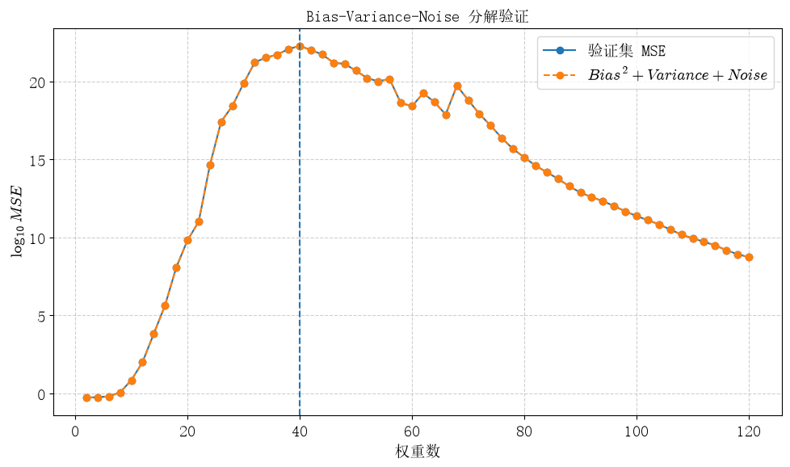

```python
fig, ax = plt.subplots(figsize=(10, 6))

ax.plot(weights_bv, np.log10(test_mse_mc), marker="o", label="验证集 MSE")
ax.plot(weights_bv, np.log10(bvn_sum), marker="o", linestyle="--",
            label=r"$Bias^2+Variance+Noise$")
ax.axvline(40, linestyle="--", linewidth=1.5)
ax.set_title("Bias-Variance-Noise 分解验证")
ax.set_xlabel("权重数")
ax.set_ylabel(r"$\log_{10} MSE$")
ax.grid(True, linestyle="--", alpha=0.6)
ax.legend()

display_inline(fig)
```

可见，验证误差与三项之和在数值上基本一致, 因而平方损失下的 Bias-Variance-Noise 分解得到验证.

进一步绘制不同部分随权重数的变化关系：

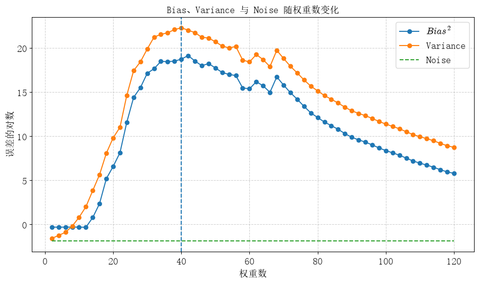

```python
fig, ax = plt.subplots(figsize=(10, 6))

ax.plot(weights_bv, np.log10(bias2), marker="o", label=r"$Bias^2$")
ax.plot(weights_bv, np.log10(variance), marker="o", label="Variance")
ax.plot(weights_bv, np.log10(noise), linestyle="--", label="Noise")

ax.axvline(40, linestyle="--", linewidth=1.5)
ax.set_title("Bias、Variance 与 Noise 随权重数变化")
ax.set_xlabel("权重数")
ax.set_ylabel("误差的对数")
ax.grid(True, linestyle="--", alpha=0.6)
ax.legend()

display_inline(fig)
```

当 $p$ 接近训练样本数 $N=40$ 时, 根据前面的实验，最小奇异值快速趋近于零, 训练数据中的微小变化会经过伪逆产生巨大的放大.

这种放大首先使不同训练数据集得到的拟合函数产生巨大差异, 因而 Variance 急剧增加. 同时在接近 $n_{weight}\approx40$ 时, 高阶多项式虽然能够几乎精确穿过所有训练点, 但在训练点之间可以产生非常剧烈的振荡. 不同随机训练集上的这种不稳定插值会使平均预测本身也偏离真实函数, 因而 Bias 同样上升.

当 $p>N$ 后, 最小非零奇异值重新增大, 伪逆的放大作用减弱. 同时 `np.linalg.lstsq` 在无穷多个插值解中选择最小范数解. 因而 Bias 和 Variance 均从插值峰附近逐渐下降.

## 对比普通多项式基底

### 使用普通多项式基底拟合

前面使用 Legendre 多项式

$$ P_0(x),P_1(x),\dots,P_{p-1}(x) $$

作为线性回归的基底. 为了分析正交基底对高阶多项式拟合稳定性的影响, 下面与普通幂函数基底

$$ 1,x,x^2,\dots,x^{p-1} $$

进行对比.

```python
@nb.njit(parallel=True)
def power_vander(x, n_weight):
    X = np.empty((x.size, n_weight))

    for i in nb.prange(x.size):
        X[i, 0] = 1.0
        for n in range(1, n_weight): X[i, n] = X[i, n-1] * x[i]
    return X

X_train_power = power_vander(x_train, max_weight)
X_val_power = power_vander(x_val, max_weight)
```

```python
train_mse_power, val_mse_power, ranks_power, s_min_power, condition_power = sweep_lstsq(
    X_train_power, y_train, X_val_power, y_val, n_weights
)
```

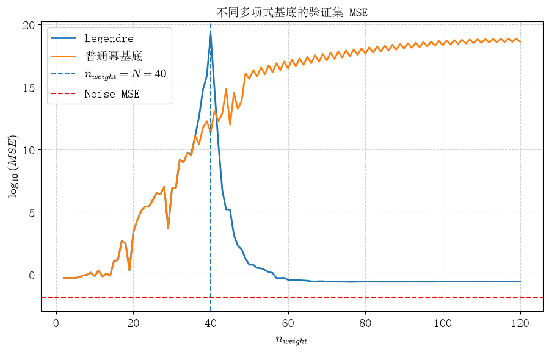

```python
fig, ax = plt.subplots(figsize=(10, 6))
ax.plot(n_weights, np.log10(val_mse), linewidth=2, label="Legendre")
ax.plot(n_weights, np.log10(val_mse_power), linewidth=2, label="普通幂基底")
ax.axvline(40, linestyle="--", linewidth=1.5, label=r"$n_{weight}=N=40$")
ax.set_title("不同多项式基底的验证集 MSE")
ax.set_xlabel(r"$n_{weight}$"); ax.set_ylabel(r"$\log_{10}(MSE)$")
ax.axhline(np.log10(noise_amplitude**2 / 3), linestyle="--", linewidth=1.5, color='r', label="Noise MSE")
ax.grid(True, linestyle="--", alpha=0.6); ax.legend()
display_inline(fig)
```

首先比较两种基底得到的验证集 MSE.

当 $n_{weight}$ 较小时，伪逆的数值误差还不明显，又因为最小二乘拟合函数是唯一的. 由于普通幂基底与 Legendre 基底张成相同的函数空间, 在精确计算下两者应该得到相同的预测结果. 因此低阶区域两条 MSE 曲线重合.

随着阶数继续增大, 两种基底的数值条件会逐渐产生明显差异. 普通幂基底开始出现严重的病态性或数值秩亏, 即使理论上的函数空间仍然相同, 实际浮点计算得到的结果也会开始偏离.

为了进一步确定差异的来源, 下面比较两种设计矩阵的奇异值.

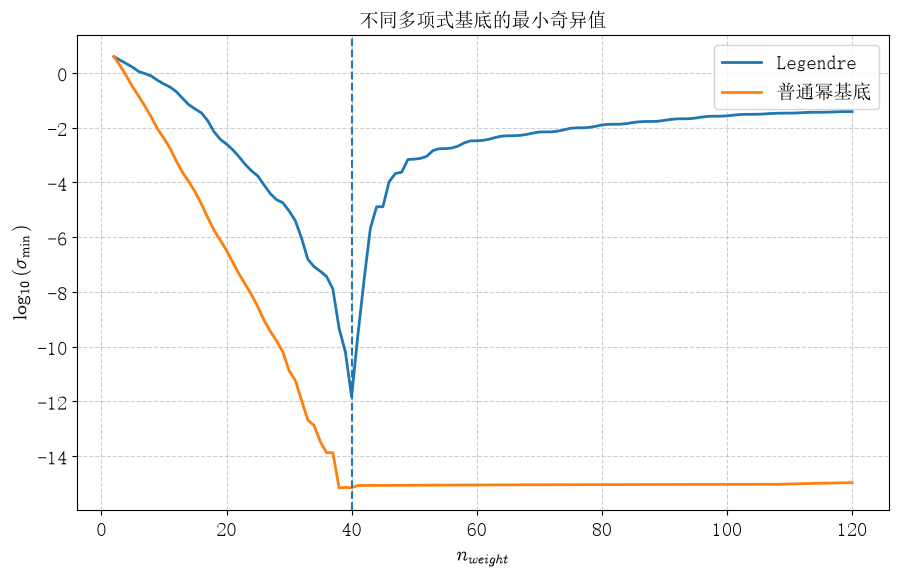

```python
fig, ax = plt.subplots(figsize=(10, 6))
ax.plot(n_weights, np.log10(s_min), linewidth=2, label="Legendre")
ax.plot(n_weights, np.log10(s_min_power), linewidth=2, label="普通幂基底")
ax.axvline(40, linestyle="--", linewidth=1.5)
ax.set_title("不同多项式基底的最小奇异值")
ax.set_xlabel(r"$n_{weight}$"); ax.set_ylabel(r"$\log_{10}(\sigma_{\min})$")
ax.grid(True, linestyle="--", alpha=0.6); ax.legend()
display_inline(fig)
```

普通幂基底的最小奇异值下降明显更快. 其原因是高阶幂函数之间具有较强的相关性. 例如在 $|x|<1$ 时, $x^n$ 和 $x^{n+2}$ 随着 $n$ 增大都会快速趋近于零, 因而在有限训练样本上越来越难以区分.

相比之下, Legendre 多项式满足连续正交关系

$$ \int_{-1}^{1}P_m(x)P_n(x)\,dx= \frac{2}{2n+1}\delta_{mn} $$

不同特征之间的相关性显著弱于普通幂基底, 因此设计矩阵能够保持更大的最小奇异值.

当普通幂基底的最小奇异值下降到接近浮点数精度时, 一些理论上仍然线性独立的方向会在数值计算中被认为近似线性相关. 此时 `np.linalg.lstsq` 会截断这些极小的奇异方向, 从而使实际求解的问题逐渐偏离理想的完整高阶多项式拟合.

另一方面，当 $n>40$ 时，可以注意到 Legendre 多项式的最小奇异值增大，但幂级数基底不会，这也导致其 MSE 随 $n$ 的变化不同. 前者是先升后降，后者只有上升.

从理论上看, 增加一个新的特征列 $\mathbf z$ 后有

$$ X_{p+1}X_{p+1}^T=X_pX_p^T+\mathbf z\mathbf z^T $$

因此最小非零奇异值不会因为增加特征而继续减小. 但是它能够增加多少, 取决于新加入的特征是否能够补充设计矩阵中原本最薄弱的方向.

Legendre 多项式不同阶之间具有正交结构, 因此进入过参数化区域后继续加入新的 Legendre 基函数, 通常能够提供与已有特征相对独立的新方向. 这些额外方向逐渐增强原来较弱的方向, 因而最小非零奇异值明显回升.

普通幂基底则不同. 高阶的 $x^n$ 与已有高阶幂函数具有很强的相关性, 新增特征主要重复已有的方向, 对设计矩阵中最薄弱方向的补充很有限. 因此即使参数数目继续增加, 最小非零奇异值也几乎没有恢复.

为了直接观察普通幂基底是否提前发生数值秩亏, 进一步比较特征矩阵的数值秩.

对于 $X\in\mathbb R^{N\times p}$, 理论上的最大秩为

$$ \min(N,p) $$

因此如果实际数值秩低于这一数值, 就说明某些基函数虽然在数学上仍然线性独立, 但在当前浮点精度下已经无法可靠地区分.

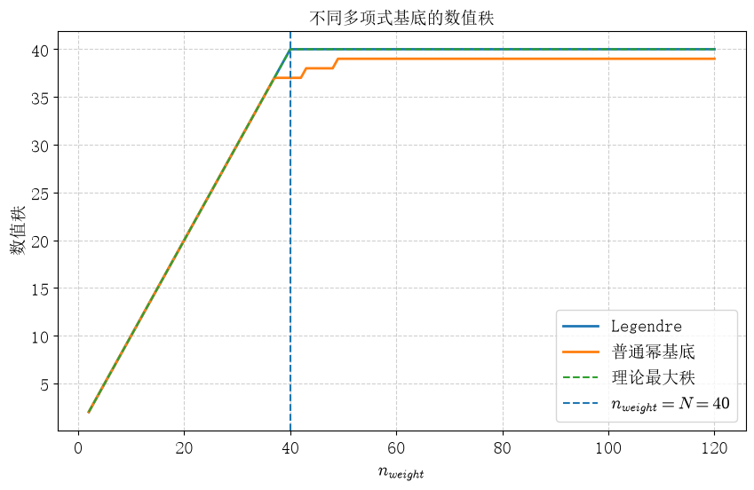

```python
fig, ax = plt.subplots(figsize=(10, 6))
ax.plot(n_weights, rank_all, linewidth=2, label="Legendre")
ax.plot(n_weights, ranks_power, linewidth=2, label="普通幂基底")
ax.plot(n_weights, np.minimum(n_weights, len(x_train)), linestyle="--", linewidth=1.5, label="理论最大秩")
ax.axvline(40, linestyle="--", linewidth=1.5, label=r"$n_{weight}=N=40$")
ax.set_title("不同多项式基底的数值秩")
ax.set_xlabel(r"$n_{weight}$"); ax.set_ylabel("数值秩")
ax.grid(True, linestyle="--", alpha=0.6); ax.legend()
display_inline(fig)
```

可以看见普通幂基底的数值秩在达到 $N=40$ 之前就低于理论最大秩, 已经提前发生数值秩亏.

这也解释了为什么普通幂基底的验证 MSE 会在高阶区域明显偏离 Legendre 基底. 此时两种方法在精确数学意义下仍然使用相同的多项式空间, 但计算机实际能够分辨和利用的特征方向已经不同.

## Legendre 多项式基底特征标准化影响

### 数值探索

对于 Legendree 多项式，我们前面没有进行特征标准化，前面我们认为标准化会改变基底的正交性质.

这里我们来分析标准化对拟合产生的影响.

```python
mu, std = X_train_all[:, 1:].mean(axis=0), X_train_all[:, 1:].std(axis=0)

X_train_std, X_val_std = X_train_all.copy(), X_val_all.copy()
X_train_std[:, 1:] = (X_train_all[:, 1:]-mu)/std
X_val_std[:, 1:] = (X_val_all[:, 1:]-mu)/std

train_mse_std, val_mse_std, rank_std, s_min_std, condition_std = sweep_lstsq(
    X_train_std, y_train, X_val_std, y_val, n_weights
)
```

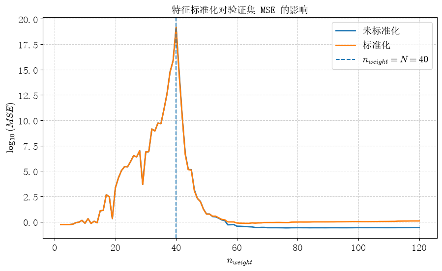

```python
fig, ax = plt.subplots(figsize=(10, 6))
ax.plot(n_weights, np.log10(val_mse), linewidth=2, label="未标准化")
ax.plot(n_weights, np.log10(val_mse_std), linewidth=2, label="标准化")
ax.axvline(40, linestyle="--", linewidth=1.5, label=r"$n_{weight}=N=40$")
ax.set_title("特征标准化对验证集 MSE 的影响")
ax.set_xlabel(r"$n_{weight}$"); ax.set_ylabel(r"$\log_{10}(MSE)$")
ax.grid(True, linestyle="--", alpha=0.6); ax.legend()
display_inline(fig)
```

从实验结果可以看出, 当 $n_{weight}<N=40$ 时, 标准化与未标准化得到的验证集 MSE 几乎完全重合. 这是因为在特征矩阵满列秩时, 最小二乘拟合函数唯一. 对特征进行逐列标准化只是对原特征作可逆线性变换, 并没有改变特征所张成的函数空间, 因而最终预测基本保持不变.

当 $n_{weight}>40$ 后, 参数数量超过训练样本数, 最小二乘问题存在无穷多个能够近似或完全插值训练数据的参数解. `np.linalg.lstsq` 此时选择系数 L2 范数最小的解. 特征标准化虽然没有改变模型能够表示的函数空间, 但改变了各个参数方向的尺度. 因此标准化和未标准化会选择不同的插值解.

实验中可以看到, 标准化后在过参数化区域中的验证集 MSE 反而略高.

我们进一步验证是标准化中的哪一部分产生了影响（平移 or 缩放），我们进一步拆成四组，不标准化，仅平移，仅仅缩放，完整标准化. 对比 MSE.

```python
mu, std = X_train_all[:, 1:].mean(0), X_train_all[:, 1:].std(0)

X_train_center, X_val_center = X_train_all.copy(), X_val_all.copy()
X_train_center[:, 1:] -= mu; X_val_center[:, 1:] -= mu

X_train_scale, X_val_scale = X_train_all.copy(), X_val_all.copy()
X_train_scale[:, 1:] /= std; X_val_scale[:, 1:] /= std


X_train_std, X_val_std = X_train_all.copy(), X_val_all.copy()
X_train_std[:, 1:] = (X_train_all[:, 1:]-mu)/std
X_val_std[:, 1:] = (X_val_all[:, 1:]-mu)/std

train_mse_center, val_mse_center, rank_center, s_min_center, condition_center = sweep_lstsq(
    X_train_center, y_train, X_val_center, y_val, n_weights)

train_mse_scale, val_mse_scale, rank_scale, s_min_scale, condition_scale = sweep_lstsq(
    X_train_scale, y_train, X_val_scale, y_val, n_weights)

train_mse_std, val_mse_std, rank_std, s_min_std, condition_std = sweep_lstsq(
    X_train_std, y_train, X_val_std, y_val, n_weights)
```

绘图，并列出最优 MSE.

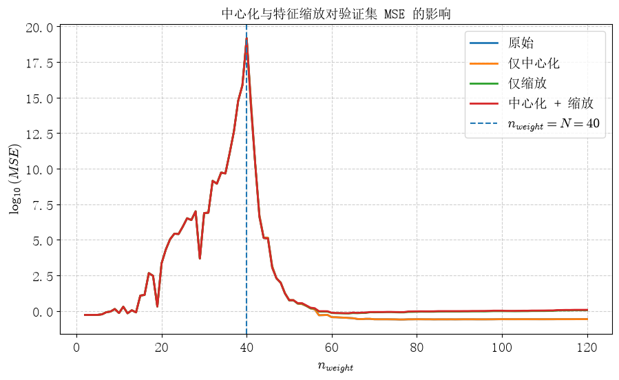

```python
fig, ax = plt.subplots(figsize=(10, 6))
ax.plot(n_weights, np.log10(val_mse), linewidth=2, label="原始")
ax.plot(n_weights, np.log10(val_mse_center), linewidth=2, label="仅中心化")
ax.plot(n_weights, np.log10(val_mse_scale), linewidth=2, label="仅缩放")
ax.plot(n_weights, np.log10(val_mse_std), linewidth=2, label="中心化 + 缩放")
ax.axvline(40, linestyle="--", linewidth=1.5, label=r"$n_{weight}=N=40$")
ax.set_title("中心化与特征缩放对验证集 MSE 的影响")
ax.set_xlabel(r"$n_{weight}$"); ax.set_ylabel(r"$\log_{10}(MSE)$")
ax.grid(True, linestyle="--", alpha=0.6); ax.legend()
display_inline(fig)
```

```python
# 四组最优验证集 MSE
results = {
    "原始": val_mse,
    "仅中心化": val_mse_center,
    "仅缩放": val_mse_scale,
    "中心化 + 缩放": val_mse_std
}

best = []
for name, mse in results.items():
    i = np.argmin(mse)
    best.append([name, n_weights[i], mse[i]])

df_best = pd.DataFrame(best, columns=["方法", r"$n_{weight}$", "最优验证集 MSE"])
display(df_best.style.format({"最优验证集 MSE": "{:.6e}"}))
```

|  | 方法 | $n_{weight}$ | 最优验证集 MSE |
| --- | --- | --- | --- |
| 0 | 原始 | 76 | 2.467197e-01 |
| 1 | 仅中心化 | 76 | 2.468397e-01 |
| 2 | 仅缩放 | 3 | 5.173127e-01 |
| 3 | 中心化 + 缩放 | 3 | 5.173127e-01 |

看起来主要影响的并不是影响正交性的中心化，而是缩放. 之前的认为“标准化影响基底正交性，使得拟合效果变差”的推论有问题. 可能微小的偏移并不会对系统的拟合造成较大影响（从标准化前的标准 Legendre 基底到标准化后的基底的变换是完全满秩的）.

但我们可以看到，缩放会对 MSE 产生较大影响，下面我们进一步探究影响的原因.

可以注意到，无论哪一种方法，差异均出现在“欠定”后，此时系统理论上有无穷多解，numpy 选择范数最小的解. 可以猜测缩放的差异源自于这个选择解的过程.

### 理论分析

对于均匀分布 $x\sim U[-1,1]$, Legendre 多项式满足

$$ \mathbb E[P_n]=0 $$

以及

$$ \mathbb E[P_n^2]=\frac{1}{2n+1} $$

因此其理论标准差为

$$ \sigma_n=\frac{1}{\sqrt{2n+1}} $$

因此标准化过程近似可以等价于

$$ P_n(x) \rightarrow \sqrt{2n+1}P_n(x) $$

但是当 $n_{weight}>N$ 时, 最小二乘解不唯一, `np.linalg.lstsq` 会选择 L2 范数最小的插值解. 对原始 Legendre 基底而言，L2 损失为：

$$ L_{2,\mathrm{raw}}=\sum_n\theta_n^2 $$

另一方面, 第 $n$ 阶 Legendre 多项式的 $L^2$ 均方能量为：

$$ E_n=\frac{\theta_n^2}{2n+1} $$

因此

$$ L_{2,\mathrm{raw}} = \sum_n (2n+1)E_n $$ 可见原始系数范数会随着阶数增加而对高阶施加更强的惩罚, 因而具有抑制高阶振荡的隐式谱正则化作用.

进行特征缩放后, 若使用缩放后的系数 $\beta_n$, 则有

$$ \beta_n=\sigma_n\theta_n $$

所以条件变为

$$ L_{2,\mathrm{scale}}=\sum_n\beta_n^2= \sum_n\sigma_n^2\theta_n^2\approx \sum_n\frac{\theta_n^2}{2n+1}=\sum_nE_n $$

因此缩放后不同阶 Legendre 模式近似按照其函数能量等权处理, 原始基底中对高阶模式额外的抑制消失.

这解释了实验结果. 在 $n_{weight}<N$ 时, 最小二乘解唯一, 特征缩放只是可逆的坐标变换, 因此不同方法的验证 MSE 基本一致. 而在 $n_{weight}>N$ 后, 原始 Legendre 基底更强地抑制高阶振荡模式, 因而在过参数化区域获得了更低的验证误差.

### 进一步验证

根据前面的推论，原始和仅中心化时，模型的低阶系数占比相比另外两个较大，因此我们进行验证：

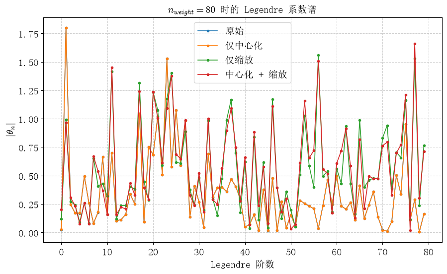

```python
p = 80
b_raw = np.linalg.lstsq(X_train_all[:, :p], y_train, rcond=None)[0]
b_center = np.linalg.lstsq(X_train_center[:, :p], y_train, rcond=None)[0]
b_scale = np.linalg.lstsq(X_train_scale[:, :p], y_train, rcond=None)[0]
b_std = np.linalg.lstsq(X_train_std[:, :p], y_train, rcond=None)[0]

t_raw = b_raw.copy()

t_center = b_center.copy()
t_center[0] = b_center[0]-mu[:p-1]@b_center[1:]

t_scale = b_scale.copy()
t_scale[1:] = b_scale[1:]/std[:p-1]

t_std = b_std.copy()
t_std[1:] = b_std[1:]/std[:p-1]
t_std[0] = b_std[0]-mu[:p-1]@t_std[1:]

fig, ax = plt.subplots(figsize=(10, 6))
ax.plot(np.arange(p), np.abs(t_raw), "o-", markersize=3, linewidth=1.2, label="原始")
ax.plot(np.arange(p), np.abs(t_center), "o-", markersize=3, linewidth=1.2, label="仅中心化")
ax.plot(np.arange(p), np.abs(t_scale), "o-", markersize=3, linewidth=1.2, label="仅缩放")
ax.plot(np.arange(p), np.abs(t_std), "o-", markersize=3, linewidth=1.2, label="中心化 + 缩放")
ax.set_title(r"$n_{weight}=80$ 时的 Legendre 系数谱")
ax.set_xlabel("Legendre 阶数"); ax.set_ylabel(r"$|\theta_n|$")
ax.grid(True, linestyle="--", alpha=0.6); ax.legend()
display_inline(fig)
```

挑选仅中心化和仅缩放作为对比，有：

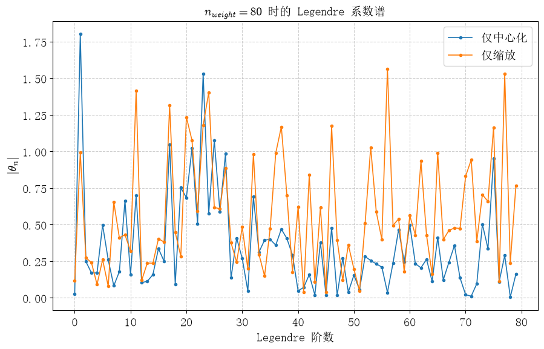

```python
fig, ax = plt.subplots(figsize=(10, 6))
#ax.plot(np.arange(p), np.abs(t_raw), "o-", markersize=3, linewidth=1.2, label="原始")
ax.plot(np.arange(p), np.abs(t_center), "o-", markersize=3, linewidth=1.2, label="仅中心化")
ax.plot(np.arange(p), np.abs(t_scale), "o-", markersize=3, linewidth=1.2, label="仅缩放")
#ax.plot(np.arange(p), np.abs(t_std), "o-", markersize=3, linewidth=1.2, label="中心化 + 缩放")
ax.set_title(r"$n_{weight}=80$ 时的 Legendre 系数谱")
ax.set_xlabel("Legendre 阶数"); ax.set_ylabel(r"$|\theta_n|$")
ax.grid(True, linestyle="--", alpha=0.6); ax.legend()
display_inline(fig)
```

可以看出，仅仅中心化相比仅缩放在 Legendre 阶数较高的部分的权重较低. 与我们前面的分析结果相符

对于未标准化，挑选 L2 最低的过程本质上是更偏向于低阶，从而避免对噪声等高阶项的拟合，防止过拟合

对于标准化，由于缩放导致这个过程缺失，从而更容易拟合噪声，因此最后 MSE 高于未标准化.

## 结论

本次实验使用 Legendre 多项式作为线性回归基底，并通过 `np.linalg.lstsq` 直接求解最小二乘问题. 在训练集仅包含 $40$ 个样本的情况下，将模型权重数从 $2$ 扫描到 $120$，进一步分析了 $n_{weight}\approx40$ 、奇异值、Bias-Variance-Noise 分解、不同多项式基底以及特征标准化对模型的影响，得到如下结论：

- 随着模型参数量增加，训练误差持续下降，并在参数数目接近训练样本数 $N=40$ 时趋近于零. 但验证误差并没有呈现传统的简单 U 型变化，而是在 $n_{weight}\approx40$ 附近出现极大的插值峰，并在进入 $n_{weight}>N$ 的过参数化区域后重新下降.
- 奇异值分析说明了插值峰附近模型不稳定性的来源. 当 $n_{weight}<N$ 时，随着特征数增加，特征矩阵的最小奇异值不断减小，在 $n_{weight}\approx40$ 附近达到极小值，因此训练数据中的微小扰动会被伪逆显著放大. 当 $n_{weight}>N$ 后，由于继续增加特征相当于向 $XX^T$ 中加入半正定项，其最小特征值可以重新增大，从而使模型逐渐离开 $n_{weight}\approx40$ 附近的极端病态区域.
- 使用 $1000$ 组随机训练数据进行了 Bias-Variance-Noise 分解验证. 数值结果表明，验证 MSE 与 $\mathrm{Bias}^2+\mathrm{Variance}+\mathrm{Noise}$ 基本一致.
- 对比普通幂函数基底与 Legendre 基底发现，在低阶且数值误差尚不明显时，两者张成相同的多项式空间，因此能够得到近似相同的最小二乘预测. 但随着阶数增加，普通幂函数形成的 Vandermonde 型矩阵迅速变得病态，其最小奇异值下降到接近浮点数精度，并在 $n_{weight}<40$ 时就开始出现数值秩亏. Legendre 基底具有更好的数值条件，因此能够在过参数化区域保持可用的特征方向，并出现明显的插值峰后下降.
- 特征标准化实验表明，当 $n_{weight}<N$ 且设计矩阵满列秩时，中心化和缩放只相当于对同一函数空间进行可逆坐标变换，因此拟合结果基本不变. 当 $n_{weight}>N$ 后，最小二乘问题具有无穷多个插值解，而 `np.linalg.lstsq` 会选择当前坐标系下范数最小的解，特征缩放会改变不同基底的“权重”，并得到不同的预测函数.
- 对 Legendre 基底而言，原始特征满足 $$ \mathbb E[P_n^2]=\frac{1}{2n+1} $$ 因此直接最小化原始 Legendre 系数的范数会对高阶项施加更大的代价. 将各列缩放到单位标准差后，这种对高阶模式的额外抑制被削弱. 本实验中表现为高阶 Legendre 系数增大，并在较高参数区域产生更大的验证误差. 相比之下，仅进行中心化对结果影响很小.

## 参考资料以及 AI 使用说明

- Alethea Power, Yuri Burda, Harri Edwards, Igor Babuschkin, Vedant Misra, Grokking: Generalization Beyond Overfitting on Small Algorithmic Datasets (arXiv: 2201.02177)
- 背景补充部分个人写出大体大纲，使用 GPT 6 Astra 生成并进行人工核验和修改.
- 代码编写使用 Deepseek V4 Flash FIM 模式进行补全和生成（尤其是绘图相关函数，基本是直接生成），经过人工核验和运行验证.
- 扫参函数由 Deepseek V4 Flash 生成，经过人工核验和运行验证，其中核心的每一个参数的训练函数由人工编写.
- 文本和公式编写使用 Deepseek V4 Flash FIM 模式进行生成和补全，经过人工核验和修改.
- Legendre 多项式标准化的理论分析由 GPT 6 Astra 提供.

## 致谢

暂无

## 附一：问题

- 这里当我们对幂级数进行正交化，得到正交基底作为新的特征函数的时候，正交的过程需要指定内积的定义，而内积的定义是有一定随意性的，选定不同的定义方式（比如选定不同的权函数）即可得到不同的正交基底（不同的特征多项式）. 那么，不同内积的选取是否对系统收敛性质有所影响？这是需要进行讨论的，受限于时间和精力没有进行进一步讨论.
- Power 等人在论文 *Grokking: Generalization Beyond Overfitting on Small Algorithmic Datasets*（arXiv:2201.02177）中发现，过参数化神经网络可能在已经完全拟合甚至记忆训练数据之后，经过进一步训练才突然出现明显的泛化能力提升，这一现象被称为 Grokking. 本实验中同样观察到模型在接近插值阈值时验证误差急剧增大，而进入更强的过参数化区域后验证误差又重新下降. 这两种现象是否具有相同或相关的数学机制？

## 附二：学习心得

暂无